# PM Comparison (Working code)

Ian Eykamp

11/16/2021

```r
# if you have already installed these libraries, comment these lines out
# install.packages("tidyverse")
# install.packages("magrittr")
```

```r
library(tidyverse)
library(magrittr)
```

Clone the repo from [<https://github.com/ianeyk/Blueprint-Modules.git>](https://github.com/ianeyk/Blueprint-Modules.git) and load the file `pmComparison.RData`.

```r
# (change the path below to the file you cloned.)
load("../Module-4-Correlation/pmComparison.RData")
```

The above chunk loads the dataframe pmComparison into memory. pmComparison has a timestamp, a PM2.5 reading, and a sensor field. The sensor field tells you whether the reading was made by a DEQ reference monitor or a PMS5003 sensor.

```r
# Take a look at the dataframe.
head(pmComparison)
```

```
## # A tibble: 6 x 3
## # Rowwise:
##   date                 pm25 sensor
##   <dttm>              <dbl> <chr>
## 1 2020-09-05 10:00:00  4.98 deq
## 2 2020-09-05 11:00:00  5.30 deq
## 3 2020-09-05 12:00:00  5.51 deq
## 4 2020-09-05 13:00:00  6.15 deq
## 5 2020-09-05 14:00:00  6.24 deq
## 6 2020-09-05 15:00:00  5.22 deq
```

```r
print(size_sum(pmComparison))
```

```
## [1] "[298 x 3]"
```

```r
print(paste(min(pmComparison$date), "to", max(pmComparison$date)))
```

```
## [1] "2020-09-05 10:00:00 to 2020-09-11 16:00:00"
```

Now create a plot of DEQ and PMS5003 data. The way the dataframe is structured makes it easy to color the data points differently based on the value of the sensor column.

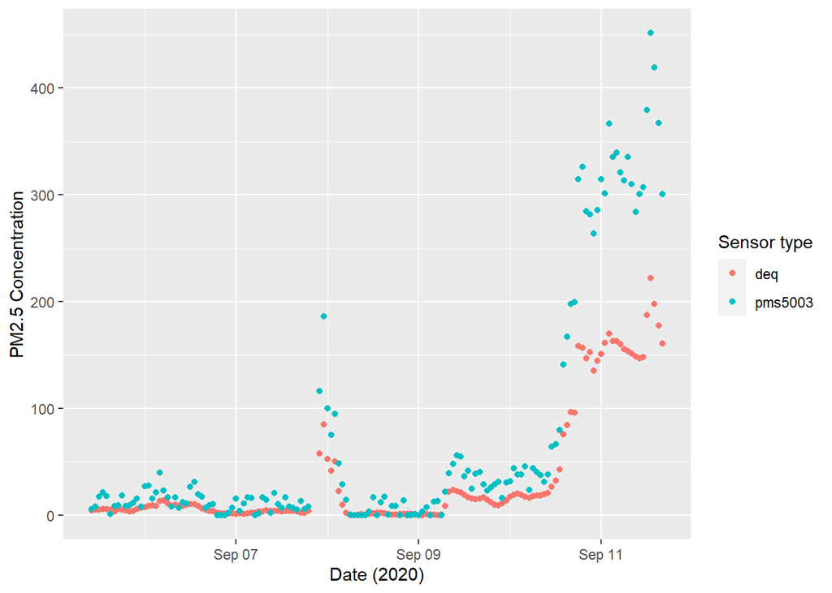

```r
ggplot(pmComparison, aes(x = date, y = pm25, color = sensor)) +
    geom_point() +
    labs(x = "Date (2020)", y = "PM2.5 Concentration", color = "Sensor type")
```

To get ready for the next step, you must convert the dataframe into a “wide” format. That is, create separate columns for the DEQ and PMS5003 sensor readings, so they can easily be plotted against each other. It is a subtle difference, but understanding this will make a huge difference in your ability to handle data.

```r
pmCompareCols <-
  pivot_wider(
    pmComparison,
    names_from = sensor,
    values_from = pm25
  )

# Take a look at the new dataframe.
head(pmCompareCols)
```

```
## # A tibble: 6 x 3
##   date                  deq pms5003
##   <dttm>              <dbl>   <dbl>
## 1 2020-09-05 10:00:00  4.98    6.28
## 2 2020-09-05 11:00:00  5.30    8.34
## 3 2020-09-05 12:00:00  5.51   17.4
## 4 2020-09-05 13:00:00  6.15   21.4
## 5 2020-09-05 14:00:00  6.24   18.0
## 6 2020-09-05 15:00:00  5.22    1.35
```

```r
# and continue your comparison code below...
# The rest of this document contains the solutions to Module 4.
```

The reason you converted the dataframe to a “wide” format is because this makes it much easier to plot two columns against each other. To compare the sensor readings between DEQ and PMS5003 devices, create a scatterplot of one reading versus the other. Add a line of best fit with geom_smooth().

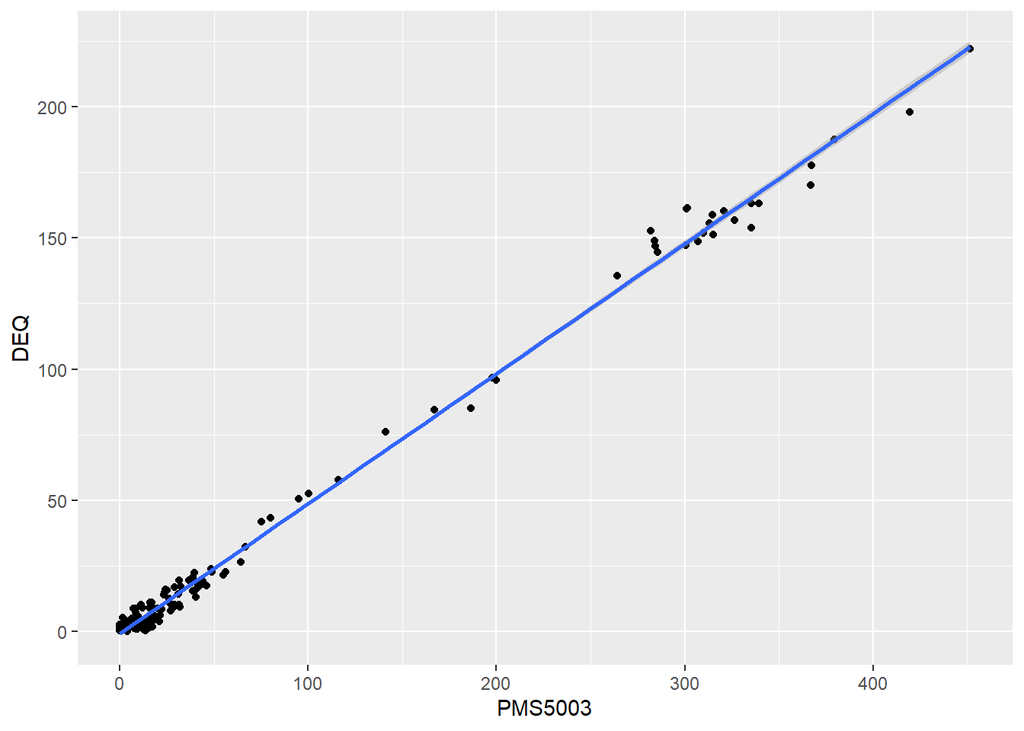

```r
ggplot(pmCompareCols, aes(x = pms5003, y = deq)) +
  geom_point() +
  geom_smooth(method = 'lm', formula = y ~ x) +
  labs(x = "PMS5003", y = "DEQ")
```

To determine the coefficients – and thus the equation – of the trend line, use lm(y ~ x). The term y ~ x means you are looking for an equation of best fit where y is proportional to x. This means an equation of the form y = mx + b

```r
x <- pmCompareCols$pms5003
y <- pmCompareCols$deq

slopeIntercept <- lm(y ~ x)
print(slopeIntercept)
```

```
##
## Call:
## lm(formula = y ~ x)
##
## Coefficients:
## (Intercept)            x
##     -0.6310       0.4948
```

The correlation coefficient tells you how strong the relationship – or correlation – is between x and y (the PMS5003 and the DEQ reference monitor.

```r
print(cor(x, y))
```

```
## [1] 0.9974499
```

The slope and intercept are stored in the coefficients variable. Store these numbers with the names `m` and `b`. Our equation tells us what we need to do to the PMS5003 data to get the DEQ data. Now that we have the coefficients of our equation, we can transform the PMS5003 data by plugging it into the equation using `mutate()`.

```r
m <- slopeIntercept$coefficients[2]
b <- slopeIntercept$coefficients[1]

pmCorrected <- pmCompareCols %>%
    mutate(pmsCorrected = m * pms5003 + b)
```

Now plot the corrected PMS5003 values against the DEQ values.

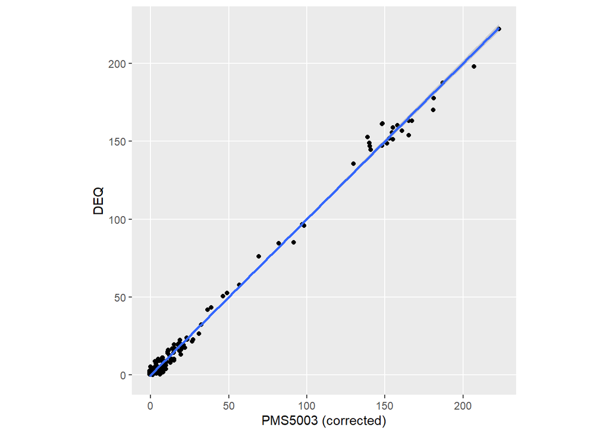

```r
ggplot(pmCorrected, aes(x = pmsCorrected, y = deq)) +
    geom_point() +
    geom_smooth(method = 'lm', formula = y ~ x) +
    labs(x = "PMS5003 (corrected)", y = "DEQ") +
    coord_fixed(1) +
    theme(
        panel.grid.minor = element_blank()
    )
```

Finally, convert the corrected data set back into a “long” format. This format is useful for plotting the sensor readings side by side over time.

```r
pmCorrectedLong <- pmCorrected %>%
    pivot_longer(cols = c(deq, pms5003, pmsCorrected),
    names_to = "sensor", values_to = "pm25")
```

Lastly, plot the data as a time series again. The data points will be colored based on the type of sensor making the readings. The corrected PMS5003 and DEQ data should be very similar over time.

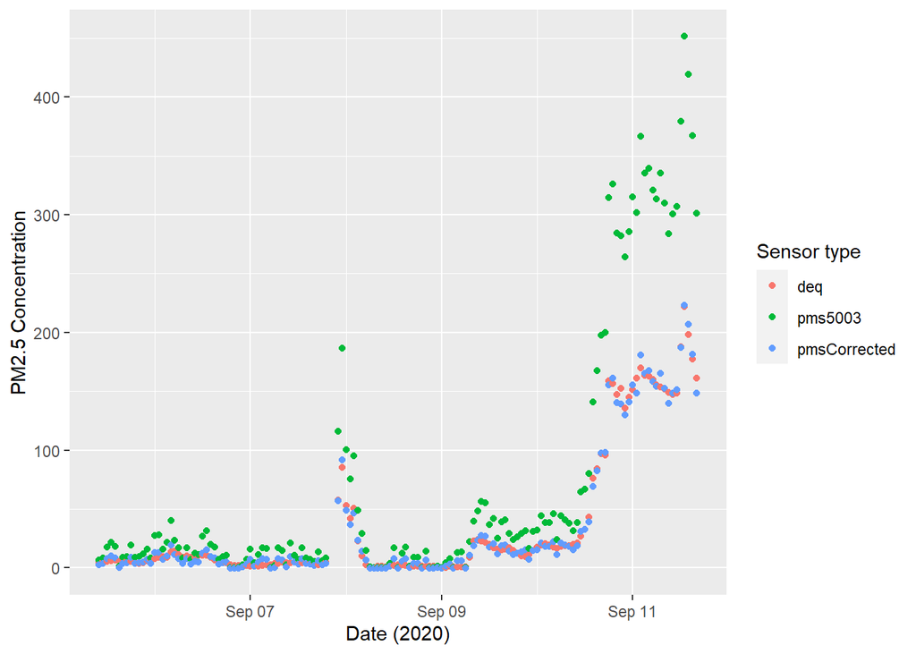

```r
ggplot(pmCorrectedLong, aes(x = date, y = pm25, color = sensor)) +
    geom_point() +
    labs(x = "Date (2020)", y = "PM2.5 Concentration", color = "Sensor type")
```